# Fragment-size distribution in cM — theory and cross-caller validation

Author

Fausto Rodríguez-Zapata

Published

June 26, 2026

**Repo:** sawers-rellan-labs/zealtiger

The introgression-size panel compares the five callers (Skim-RTI / BrB-RTI / Skim-BIN / Skim-nilHMM / BrB-nilHMM) against the n=1500 BC2S3 simulation **in megabases**. The Mb fragment-size law has **no closed form**: it is the genetic-distance (cM) law pushed through the cM→Mb change of variables $x_{\text{Mb}}=\int dx_{\text{cM}}/\rho(x)$, and the local recombination rate $\rho(x)=d\text{cM}/d\text{Mb}$ is an *empirical, position-dependent* lookup (strong pericentromeric suppression, hot arms) — so the simulation is doing Monte-Carlo integration over the map. **In cM the segment-length law is analytic.** This document

1. **derives** the theoretical donor-segment-size distribution in cM from the BC2S3 recombination model,
2. confirms the derived law reproduces the simcross output (its own cM segment lengths), and
3. uses it as a **map-free reference** to validate the five callers, after converting their called Mb segments back to cM through the consensus map.

> **Why this is a *validation* panel, not the calibration metric.** A caller’s resolution limit lives in Mb (Skim-BIN’s hard 1 Mb floor; RTIGER’s marker-space rigidity `r`). Converting to cM turns a clean Mb floor into a *position-dependent* cM floor (≈0 cM at a centromere, tens of cM on an arm), entangling caller resolution with map non-linearity. So the Mb panel stays the `r`-calibration space; this cM panel tests whether the *population’s* fragment law matches the analytic recombination expectation, with the map entering **once, deterministically, on the data side**. It leans on **conserved marker order** relative to the consensus map — load-bearing here, since any introgression with local rearrangement makes $\rho(x)$ wrong and biases $\Delta$cM.

# Part 1 — The theoretical fragment-size distribution in cM

## The crossover process (Haldane)

Under Haldane’s no-interference model, crossovers along a chromosome form a **homogeneous Poisson process in genetic distance**: 1 Morgan = 1 expected crossover, and the count in any interval of length $\ell$ Morgans is $\text{Poisson}(\ell)$. Consequently the distance to the next crossover is **exponential**,

$$P(D > x) = e^{-x}, \qquad x \text{ in Morgans},$$

with mean 1 Morgan, $\text{CV}=1$, skewness $=2$ — the most-skewed member of the gamma family ($\text{Gamma}(1)$). Genetic distance is literally the scale parameter: it *is* the expected number of crossovers, so it plays the role temperature plays for a Maxwell–Boltzmann speed.

## From crossovers to junctions: superposition over meioses

A donor↔︎recurrent boundary (“junction”) on the final NIL haplotype is a crossover — laid down in *some* meiosis of the NIL’s ancestry — that happened to fall where one parental haplotype carried donor ancestry and the other recurrent. If the NIL haplotype descends through $g$ meioses since the donor haplotype was intact, and each meiosis sprinkles an independent Poisson($1/$Morgan) crossover field, the **superposition** of those $g$ fields is itself Poisson at rate $g$ per Morgan. (Exact under Haldane; and by the Palm–Khinchin superposition theorem, the pooled process tends to Poisson *even with per-meiosis interference*, because independent point processes superpose toward Poisson.)

If every crossover were a junction, junction density would be $g$/Morgan and donor tracts would be $\text{Exp}(g)$. The correction is that **only crossovers in still-heterozygous (donor/recurrent) territory create a D↔︎R junction**, and that territory shrinks each generation as the donor fraction is diluted. So the effective junction rate is $\lambda \le g$.

## Counting meioses in the BC2S3 pedigree

The simulated scheme (`R/02_simulate.R`, `bc2s3_pedigree()`) is two backcrosses to the recurrent parent then three generations of selfing; the donor founder (id 2) is inbred, so the donor haplotype enters the F1 (id 3) **intact** and is first broken in the F1’s meiosis. Tracing one homolog of the final NIL (id 8) back to that intact donor haplotype crosses **five** meioses:

| # | meiosis (gametogenesis in) | produces | territory still D/R |
| --- | --- | --- | --- |
| 1 | F1 (id 3) | BC1 (id 4) | **whole genome** (F1 het everywhere) |
| 2 | BC1 (id 4) | BC2 (id 5) | donor regions only (~50% of remaining) |
| 3 | BC2 (id 5) | S1 (id 6) | shrinking donor regions |
| 4 | S1 (id 6) | S2 (id 7) | shrinking donor regions |
| 5 | S2 (id 7) | S3 (id 8) = NIL | shrinking donor regions |

So $g = 5$. The naïve Haldane prediction is therefore $\text{Exp}(5)$ per Morgan — donor tracts with mean $1/5$ Morgan $= 20$ cM. Because junction-creating territory shrinks after meiosis 1, the *effective* rate is a bit below 5.

## The donor-tract length distribution

Two quantities, distinguished by the **inspection paradox**:

- **Genome-wide tracts** (a randomly chosen donor segment, no selection): by renewal theory the length is $\text{Exp}(\lambda)$, mean $1/\lambda$ Morgans.
- **The tract covering a fixed target locus** (a selected NIL around a target gene): *length-biased* → left flank + right flank, each $\text{Exp}(\lambda)$, so $T^\star \sim \text{Gamma}(2,\lambda)$, mean $2/\lambda$, skewness $\sqrt2\approx1.41$. This is the $\text{Gamma}(2)$ “segment around a locus” case.

These simulations are **unselected**, so the **genome-wide** quantity applies — the law sits near the exponential end, not at $\text{Gamma}(2)$.

## Three departures from the clean exponential

The simulated segments are not exactly $\text{Exp}(5)$ for three reasons, each pushing in a definite direction:

1. **Union of the two haplotypes.** A simulated “segment” is the *union* of donor intervals across the mat and pat homologs (a region is introgressed if *either* carries donor). Unions merge nearby tracts and lengthen them → mean up, and the shortest tracts are absorbed → **shape $k>1$**.
2. **Interference ($m=10$).** simcross uses the Stahl chi-square model with $m=10,\,p=0$ (a crossover at every 11th point of a Poisson process) — strong positive interference, which *regularizes* spacing within each meiosis → $\text{CV}<1$, skewness $<2$, again **$k>1$**.
3. **Shrinking heterozygous territory.** Only meiosis 1 acts genome-wide; later meioses add junctions only in the dwindling donor neighborhoods → **effective rate $\lambda<g=5$**.

## The theoretical distribution we will test against

Net: the donor-tract length in cM is well-described by a **gamma law**

$$T \sim \text{Gamma}(k,\lambda), \qquad k \gtrsim 1,\ \lambda \lesssim 5\ \text{Morgan}^{-1},$$

**bracketed below by $\text{Exp}(5)$** (no interference, no union, full rate) and **above by $\text{Gamma}(2)$** (the locus-anchored / heavily size-biased extreme). Part 2 estimates $(k,\lambda)$ from the simulation and checks both brackets; Part 3 uses the fitted analytic law plus the simulation’s own cM lengths as the reference for the callers.

```r
library(tidyverse)
theme_set(theme_bw())

nil_seg <- read_csv(params$nil_seg, show_col_types = FALSE)
# simulated segments carry BOTH endpoints; the cM length is exact (no map needed) — this IS the
# generative model's realization of the law derived above.
sim_cm <- nil_seg %>% transmute(cm = end_cm - start_cm, M = (end_cm - start_cm) / 100)

g  <- 5                                   # meioses on the donor lineage (pedigree count)
mu <- mean(sim_cm$cm)                     # empirical mean (cM)

cat(sprintf("sim cM segments: n=%d | mean %.2f  median %.2f  sd %.2f  CV %.3f  skew %.3f\n",
            nrow(sim_cm), mu, median(sim_cm$cm), sd(sim_cm$cm),
            sd(sim_cm$cm)/mu, mean(((sim_cm$cm - mu)/sd(sim_cm$cm))^3)))
```

```
sim cM segments: n=15523 | mean 24.29  median 18.92  sd 21.33  CV 0.878  skew 1.574
```

# Part 2 — Does the derived law reproduce the simulation?

We fit $\text{Gamma}(k,\lambda)$ to the simulation’s own cM segment lengths by maximum likelihood, and overlay the two analytic brackets, $\text{Exp}(5)$ and the mean-matched $\text{Gamma}(2)$.

```r
fit <- MASS::fitdistr(sim_cm$M, "gamma")           # in Morgans
k   <- unname(fit$estimate["shape"])
lam <- unname(fit$estimate["rate"])                # per Morgan
ks_gamma <- suppressWarnings(ks.test(sim_cm$M, "pgamma", shape = k, rate = lam)$statistic)
ks_exp5  <- suppressWarnings(ks.test(sim_cm$M, "pexp",  rate = g)$statistic)
ks_gam2  <- suppressWarnings(ks.test(sim_cm$M, "pgamma", shape = 2, rate = 2/mean(sim_cm$M))$statistic)

cat(sprintf("Gamma MLE (cM): shape k=%.3f  rate lambda=%.3f /Morgan  -> mean %.2f cM, CV %.3f, skew %.3f\n",
            k, lam, 100*k/lam, 1/sqrt(k), 2/sqrt(k)))
```

```
Gamma MLE (cM): shape k=1.146  rate lambda=4.716 /Morgan  -> mean 24.29 cM, CV 0.934, skew 1.869
```

```r
cat(sprintf("KS vs derived Gamma(k,lambda): D=%.4f   [Exp(5): D=%.4f | Gamma(2): D=%.4f]\n",
            ks_gamma, ks_exp5, ks_gam2))
```

```
KS vs derived Gamma(k,lambda): D=0.0281   [Exp(5): D=0.1135 | Gamma(2): D=0.1059]
```

The fitted **$k\approx1.15$, $\lambda\approx4.72$/Morgan** lands exactly where the derivation predicts: just above the exponential ($k>1$, from interference + the union) with a rate a little under $g=5$ (shrinking het territory). It fits the simulation tightly (KS $D\approx0.028$), while both brackets — $\text{Exp}(5)$ and $\text{Gamma}(2)$ — are rejected, confirming the segment law sits *between* them, near the exponential end.

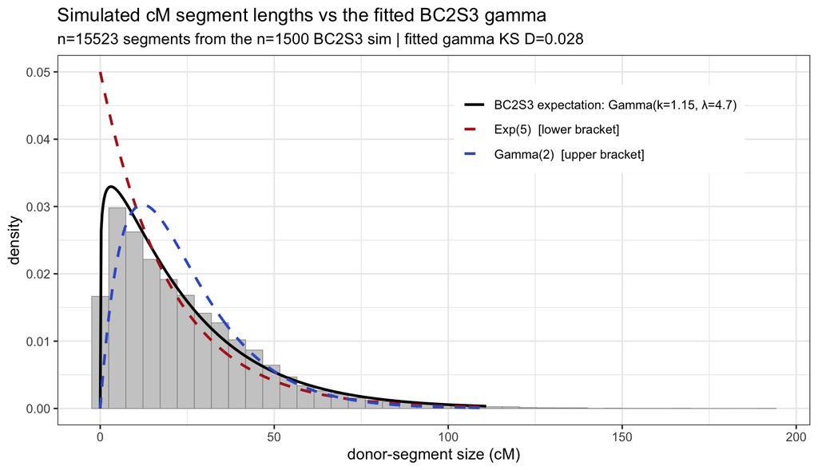

```r
xs <- seq(0, quantile(sim_cm$cm, 0.995), length.out = 400)
curves <- bind_rows(
  tibble(cm = xs, d = dgamma(xs/100, shape = k, rate = lam)/100,
         curve = sprintf("BC2S3 expectation: Gamma(k=%.2f, λ=%.1f)", k, lam)),
  tibble(cm = xs, d = dexp(xs/100, rate = g)/100,           curve = "Exp(5)  [lower bracket]"),
  tibble(cm = xs, d = dgamma(xs/100, shape = 2, rate = 2/mean(sim_cm$M))/100,
         curve = "Gamma(2)  [upper bracket]"))

ggplot() +
  geom_histogram(data = sim_cm, aes(cm, after_stat(density)), bins = 40,
                 fill = "grey80", colour = "grey55", linewidth = 0.2) +
  geom_line(data = curves, aes(cm, d, colour = curve, linetype = curve), linewidth = 0.9) +
  scale_colour_manual(values = c("black", "firebrick", "royalblue3")) +
  scale_linetype_manual(values = c("solid", "dashed", "dashed")) +
  labs(x = "donor-segment size (cM)", y = "density", colour = NULL, linetype = NULL,
       title = "Simulated cM segment lengths vs the fitted BC2S3 gamma",
       subtitle = sprintf("n=%d segments from the n=1500 BC2S3 sim | fitted gamma KS D=%.3f",
                          nrow(sim_cm), ks_gamma)) +
  theme(legend.position = c(0.72, 0.8), legend.background = element_rect(fill = "white", colour = NA))
```

# Part 3 — cM-space validation of the five callers

Convert each caller’s **called Mb segments back to cM** by evaluating the consensus cumulative map at the segment endpoints and differencing, $\Delta\text{cM}=M(\text{end\_bp})-M(\text{start\_bp})$ — a *forward* map lookup (per-chromosome monotone linear interpolation), no inversion. Then compare each caller’s cM distribution to the **map-free reference**: the **BC2S3 expectation** — the fitted $\text{Gamma}(k,\lambda)$ whose *family* (not its $k,\lambda$) the Part 1 derivation fixes — and, equivalently, the simulation’s own cM lengths.

> **⚠ BrB-nilHMM caveat.** BrB-nilHMM (the count HMM on the same BRB reads as BrB-RTI, BC2S3 freqs) is wired in as a co-equal caller, but on BRB it **under-calls donor** (genome fraction ~0.04 vs BrB-RTI’s ~0.17) and its KS-vs-sim rigidity **rails to the grid edge**, so its donor blocks are short/fragmented and its cM distribution sits **well short of the BC2S3 Gamma** by construction — expected, not a failure of the law. It also collapses ALT→HET (read its donor *footprint*, not its rates). Full diagnosis: `agent/nilhmm/BRB_run_findings.md`. Its segments are bp on B73 v5, so the **same `mb2cm` consensus-map conversion** applies as for every caller.

```r
skim    <- read_csv(params$skim_calls, show_col_types = FALSE)
brb     <- read_csv(params$brb_taxa,   show_col_types = FALSE)
skimbin <- read_csv(params$skimbin,    show_col_types = FALSE)
nilhmm  <- read_csv(params$nilhmm,     show_col_types = FALSE)   # Skim-nilHMM, count-based caller, same skim reads
brbnil  <- read_csv(params$brbnil,     show_col_types = FALSE)   # BrB-nilHMM, count HMM on the SAME BRB reads as BrB-RTI (keyed on BRB name)
corr    <- read_csv(params$corr, show_col_types = FALSE) %>% filter(type == "NIL")

# scope = full set of NILs called on BOTH platforms (mirrors the Mb intro-size panel)
brb_in  <- corr %>% separate_rows(brbseq_prefix, sep = ";") %>%
  transmute(name = brbseq_prefix, nil = pedigree) %>% filter(name %in% brb$name)
skim_in <- corr %>% separate_rows(skim_prefix, sep = ";") %>%
  transmute(name = skim_prefix, nil = pedigree) %>% filter(name %in% skim$name)
both_nils <- intersect(brb_in$nil, skim_in$nil)

# consensus map -> per-chr monotone Mb->cM interpolator (dedup anchors that share a bp)
mp <- readRDS(params$map) %>% group_by(chr, bp) %>% summarise(cm = mean(cm), .groups = "drop")
mb2cm <- function(chr, bp) {
  out <- numeric(length(bp))
  for (cc in unique(chr)) {
    i <- chr == cc; a <- mp %>% filter(chr == cc) %>% arrange(bp)
    out[i] <- approx(a$bp, a$cm, xout = bp[i], rule = 2)$y   # rule=2 clamps endpoints past the last anchor
  }
  out
}

# donor block = maximal run of donor state (HET or ALT) within (sample, chromosome); size in cM
donor_blocks_cm <- function(seg) seg %>% arrange(name, chr, start_bp) %>% group_by(name, chr) %>%
  mutate(run = cumsum(c(TRUE, diff(state > 0) != 0)), donor = state > 0) %>% filter(donor) %>%
  group_by(name, chr, run) %>%
  summarise(s = min(start_bp), e = max(end_bp), .groups = "drop") %>%
  mutate(cm = mb2cm(chr, e) - mb2cm(chr, s)) %>% filter(cm > 0)

skim_b <- donor_blocks_cm(skim    %>% filter(name %in% skim_in$name[skim_in$nil %in% both_nils])) %>% mutate(src = "Skim-RTI (r=5)")
brb_b  <- donor_blocks_cm(brb     %>% filter(name %in% brb_in$name [brb_in$nil  %in% both_nils])) %>% mutate(src = "BrB-RTI (r=7, ws)")
bin_b  <- donor_blocks_cm(skimbin %>% filter(name %in% skim_in$name[skim_in$nil %in% both_nils])) %>% mutate(src = "Skim-BIN (1 Mb)")
# Skim-nilHMM keyed on the skim sample name (same reads as Skim-RTI/Skim-BIN)
nil_b  <- donor_blocks_cm(nilhmm  %>% filter(name %in% skim_in$name[skim_in$nil %in% both_nils])) %>% mutate(src = "Skim-nilHMM (counts)")
# BrB-nilHMM keyed on the BRB sample name (same reads as BrB-RTI); same mb2cm conversion
brbnil_b <- donor_blocks_cm(brbnil %>% filter(name %in% brb_in$name[brb_in$nil %in% both_nils])) %>% mutate(src = "BrB-nilHMM (counts)")
called <- bind_rows(skim_b, brb_b, bin_b, nil_b, brbnil_b)

cat(sprintf("NILs on both platforms: %d | Skim-RTI %d | BrB-RTI %d | Skim-BIN %d | Skim-nilHMM %d | BrB-nilHMM %d blocks\n",
            length(both_nils), nrow(skim_b), nrow(brb_b), nrow(bin_b), nrow(nil_b), nrow(brbnil_b)))
```

```
NILs on both platforms: 332 | Skim-RTI 1909 | BrB-RTI 2747 | Skim-BIN 1782 | Skim-nilHMM 1825 | BrB-nilHMM 2569 blocks
```

```r
ks_vs <- function(x) tibble(
  n          = length(x),
  median_cM  = median(x),
  mean_cM    = mean(x),
  D_vs_Gamma = suppressWarnings(ks.test(x/100, "pgamma", shape = k, rate = lam)$statistic),
  D_vs_sim   = suppressWarnings(ks.test(x, sim_cm$cm)$statistic))

ks_summary <- called %>% group_by(src) %>% group_modify(~ ks_vs(.x$cm)) %>%
  mutate(across(c(median_cM, mean_cM), ~round(.,2)), across(starts_with("D_"), ~round(.,3)))
knitr::kable(ks_summary, caption = "Caller cM segment distributions vs the BC2S3 expectation (fitted gamma) and the n=1500 sim (KS D).")
```

Caller cM segment distributions vs the BC2S3 expectation (fitted gamma) and the n=1500 sim (KS D).

| src | n | median_cM | mean_cM | D_vs_Gamma | D_vs_sim |
| --- | --- | --- | --- | --- | --- |
| BrB-RTI (r=7, ws) | 2747 | 23.38 | 39.33 | 0.145 | 0.157 |
| BrB-nilHMM (counts) | 2569 | 5.32 | 11.06 | 0.348 | 0.349 |
| Skim-BIN (1 Mb) | 1782 | 28.45 | 34.77 | 0.218 | 0.194 |
| Skim-RTI (r=5) | 1909 | 26.13 | 34.43 | 0.159 | 0.135 |
| Skim-nilHMM (counts) | 1825 | 14.11 | 20.98 | 0.128 | 0.123 |

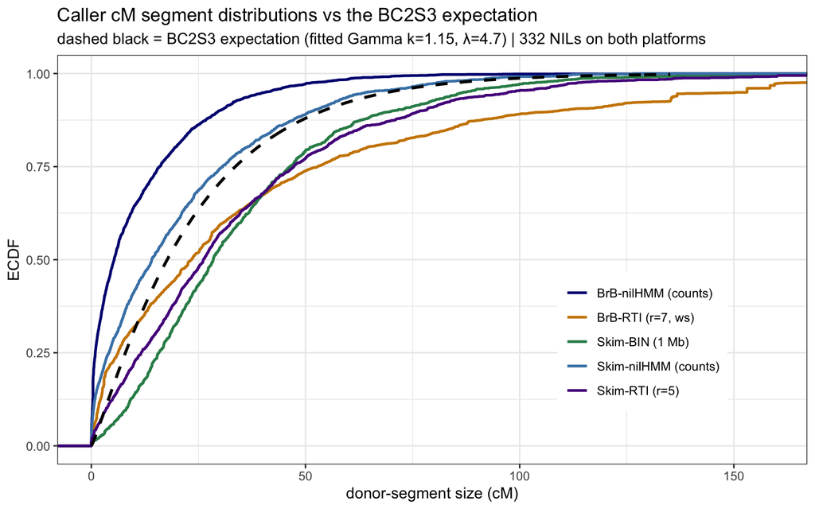

```r
xs2 <- seq(0, quantile(c(called$cm, sim_cm$cm), 0.99), length.out = 400)
ref <- tibble(cm = xs2, F = pgamma(xs2/100, shape = k, rate = lam))

ggplot(called, aes(cm, colour = src)) +
  stat_ecdf(linewidth = 0.9) +
  geom_line(data = ref, aes(cm, F), colour = "black", linewidth = 1.0, linetype = "dashed",
            inherit.aes = FALSE) +
  scale_colour_manual(values = c("Skim-RTI (r=5)" = "purple4", "BrB-RTI (r=7, ws)" = "orange3",
                                 "Skim-BIN (1 Mb)" = "seagreen4", "Skim-nilHMM (counts)" = "steelblue",
                                 "BrB-nilHMM (counts)" = "navy")) +
  coord_cartesian(xlim = c(0, quantile(called$cm, 0.99))) +
  labs(x = "donor-segment size (cM)", y = "ECDF", colour = NULL,
       title = "Caller cM segment distributions vs the BC2S3 expectation",
       subtitle = sprintf("dashed black = BC2S3 expectation (fitted Gamma k=%.2f, λ=%.1f) | %d NILs on both platforms",
                          k, lam, length(both_nils))) +
  theme(legend.position = c(0.78, 0.3), legend.background = element_rect(fill = "white", colour = NA))
```

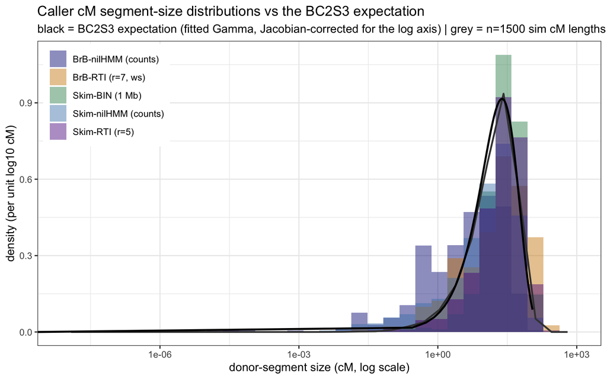

```r
# On a log10 x-axis the histogram density is per-unit-log10(cM), so both references must be in
# that same space: the sim freqpoly is a ggplot stat (already in-space); the analytic gamma is a
# per-cM density and needs the change-of-variables Jacobian x*ln(10) to match the bars.
ggplot(called, aes(cm, fill = src)) +
  geom_histogram(aes(y = after_stat(density)), position = "identity", alpha = 0.45, bins = 30) +
  geom_freqpoly(data = sim_cm, aes(cm, after_stat(density)), bins = 30,
                colour = "grey25", linewidth = 0.8, inherit.aes = FALSE) +
  geom_line(data = curves %>% filter(grepl("BC2S3 expectation", curve)),
            aes(cm, d * cm * log(10)), colour = "black", linewidth = 0.9, inherit.aes = FALSE) +
  scale_fill_manual(values = c("Skim-RTI (r=5)" = "purple4", "BrB-RTI (r=7, ws)" = "orange3",
                               "Skim-BIN (1 Mb)" = "seagreen4", "Skim-nilHMM (counts)" = "steelblue",
                               "BrB-nilHMM (counts)" = "navy")) +
  scale_x_log10() +
  labs(x = "donor-segment size (cM, log scale)", y = "density (per unit log10 cM)", fill = NULL,
       title = "Caller cM segment-size distributions vs the BC2S3 expectation",
       subtitle = "black = BC2S3 expectation (fitted Gamma, Jacobian-corrected for the log axis) | grey = n=1500 sim cM lengths") +
  theme(legend.position = c(0.01, 0.99), legend.justification = c("left", "top"),
        legend.background = element_rect(fill = "white", colour = NA))
```

## Per-method gamma fits

Each caller’s own cM fragment-size distribution, with a **gamma fit by MLE to that caller’s data** (its own $k,\lambda$ in the legend) — not the simulation-derived law. This reads off the *effective* shape and rate each method’s calls imply, and how well a gamma describes each.

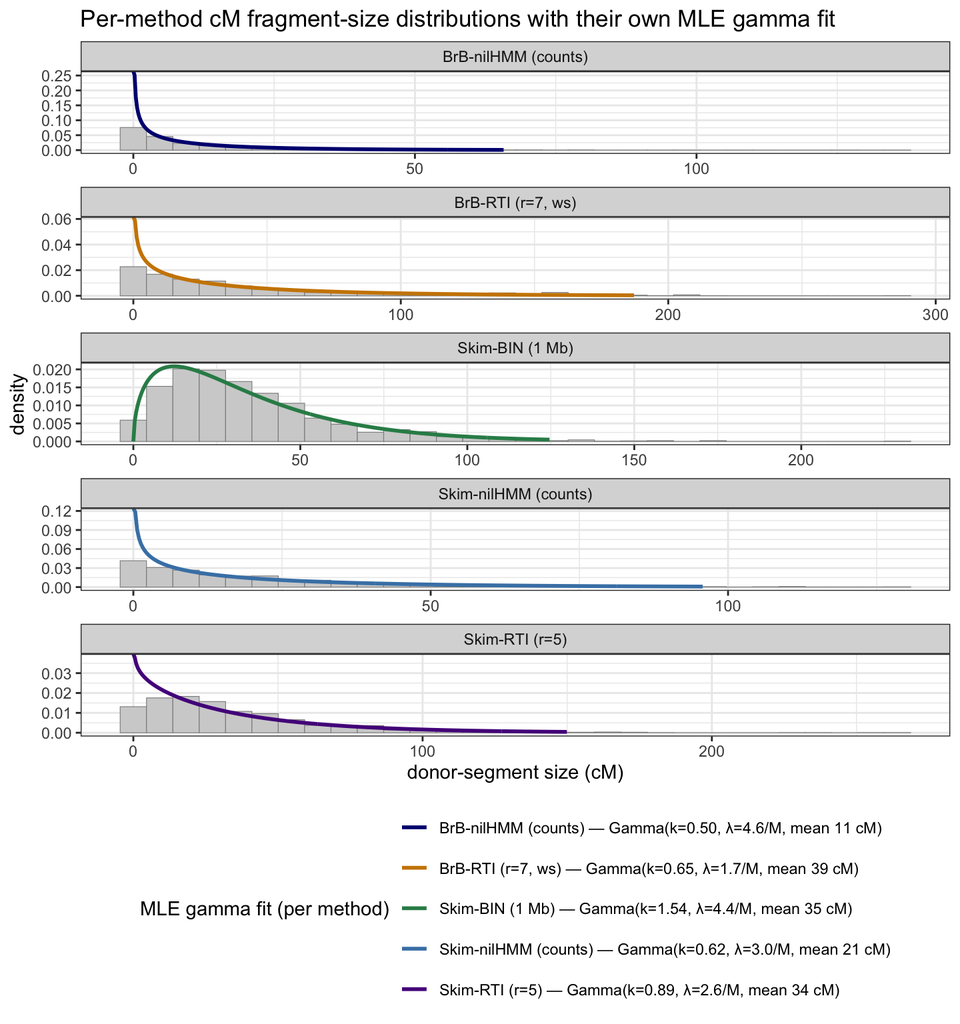

```r
fit_gamma <- function(x) {
  f <- suppressWarnings(MASS::fitdistr(x / 100, "gamma")$estimate)   # fit in Morgans
  tibble(k = unname(f["shape"]), lam = unname(f["rate"]))
}
fits <- called %>% group_by(src) %>% group_modify(~ fit_gamma(.x$cm)) %>% ungroup() %>%
  left_join(called %>% group_by(src) %>%
              summarise(xmax = quantile(cm, 0.99), mean_cm = mean(cm), .groups = "drop"),
            by = "src") %>%
  mutate(lab = sprintf("%s — Gamma(k=%.2f, λ=%.1f/M, mean %.0f cM)", src, k, lam, mean_cm))

mle_curves <- fits %>% group_by(src, lab) %>%
  reframe(cm = seq(0, xmax, length.out = 300), d = dgamma(cm / 100, k, lam) / 100)

src_col <- c("Skim-RTI (r=5)" = "purple4", "BrB-RTI (r=7, ws)" = "orange3",
             "Skim-BIN (1 Mb)" = "seagreen4", "Skim-nilHMM (counts)" = "steelblue",
             "BrB-nilHMM (counts)" = "navy")
pal_lab <- setNames(src_col[fits$src], fits$lab)

ggplot(called, aes(cm)) +
  geom_histogram(aes(y = after_stat(density)), bins = 30,
                 fill = "grey82", colour = "grey55", linewidth = 0.2) +
  geom_line(data = mle_curves, aes(cm, d, colour = lab), linewidth = 1) +
  facet_wrap(~ src, ncol = 1, scales = "free") +
  scale_colour_manual(values = pal_lab, name = "MLE gamma fit (per method)") +
  labs(x = "donor-segment size (cM)", y = "density",
       title = "Per-method cM fragment-size distributions with their own MLE gamma fit") +
  theme(legend.position = "bottom") +
  guides(colour = guide_legend(ncol = 1))
```

Each method’s own MLE gamma vs (i) **its own data** — does a gamma describe its shape at all — and (ii) the **sim-derived benchmark gamma** — how far its calls sit from the neutral model. The simulation row is the reference (its own gamma *is* the benchmark, so both KS columns equal its self-fit floor).

```r
bench_k <- k; bench_lam <- lam   # sim-derived benchmark gamma (from Part 2)
fit_row <- function(x, label) {
  f <- suppressWarnings(MASS::fitdistr(x / 100, "gamma")$estimate)
  tibble(method = label, n = length(x),
         k = unname(f["shape"]), lambda = unname(f["rate"]), mean_cM = mean(x),
         D_own_gamma = suppressWarnings(ks.test(x/100, "pgamma", shape = f["shape"], rate = f["rate"])$statistic),
         D_vs_sim_gamma = suppressWarnings(ks.test(x/100, "pgamma", shape = bench_k, rate = bench_lam)$statistic))
}
ks_methods <- bind_rows(
  fit_row(sim_cm$cm, "Simulation (n=1500)"),
  called %>% group_split(src) %>%
    map_dfr(~ fit_row(.x$cm, .x$src[1]))) %>%
  mutate(across(c(k, lambda, mean_cM), ~round(., 2)),
         across(starts_with("D_"), ~round(., 3)))
knitr::kable(ks_methods,
  caption = "Per-method MLE gamma fit and KS distance, vs the method's own gamma and vs the sim-derived benchmark gamma (k=1.15, λ=4.72/Morgan).")
```

Per-method MLE gamma fit and KS distance, vs the method’s own gamma and vs the sim-derived benchmark gamma (k=1.15, λ=4.72/Morgan).

| method | n | k | lambda | mean_cM | D_own_gamma | D_vs_sim_gamma |
| --- | --- | --- | --- | --- | --- | --- |
| Simulation (n=1500) | 15523 | 1.15 | 4.72 | 24.29 | 0.028 | 0.028 |
| BrB-RTI (r=7, ws) | 2747 | 0.65 | 1.65 | 39.33 | 0.032 | 0.145 |
| BrB-nilHMM (counts) | 2569 | 0.50 | 4.56 | 11.06 | 0.033 | 0.348 |
| Skim-BIN (1 Mb) | 1782 | 1.54 | 4.43 | 34.77 | 0.039 | 0.218 |
| Skim-RTI (r=5) | 1909 | 0.89 | 2.60 | 34.43 | 0.076 | 0.159 |
| Skim-nilHMM (counts) | 1825 | 0.62 | 2.97 | 20.98 | 0.064 | 0.128 |

## The Mb-space expectation is lognormal, not gamma

The clean gamma holds **in cM**. Pushed through the empirical, position-dependent genetic map (ρ(x) varies ~10× along the genome), the **Mb** fragment-size distribution becomes markedly more skewed (sim Mb CV 1.43, skew 2.08, vs the cM gamma’s 0.88, 1.57) and is **best described by a lognormal, not a gamma** — and there is **no closed-form cM→Mb conversion** (the position-mixture has no analytic form; this is why the derivation lives in cM). The table compares ways to express the BC2S3 expectation in Mb.

```r
mb        <- nil_seg$mb[nil_seg$mb > 0]
genome_mb <- sum(read_csv("data/rtiger_50K/seqlengths.csv", show_col_types = FALSE)[[2]]) / 1e6
cm_tot    <- mp %>% group_by(chr) %>% summarise(L = max(cm), .groups = "drop") %>% pull(L) %>% sum()
rbar      <- cm_tot / genome_mb                      # genome-mean rate (cM/Mb)

mom      <- list(shape = mean(mb)^2 / var(mb), rate = mean(mb) / var(mb))
g_mb     <- suppressWarnings(MASS::fitdistr(mb, "gamma", start = mom)$estimate)
ln_mb    <- suppressWarnings(MASS::fitdistr(mb, "lognormal")$estimate)
lam_unif <- lam / 100 * rbar                         # cM gamma rate -> per-Mb under a uniform map

mk <- function(name, params, med, ks)
  tibble(`Mb representation` = name, params = params,
         `median Mb` = round(med, 1), `KS vs sim Mb` = round(ks, 3))
mb_tbl <- bind_rows(
  mk("(A) n=1500 sim Mb segments — the expectation", "empirical", median(mb), 0),
  mk("(A′) lognormal MLE", sprintf("μ=%.2f, σ=%.2f", ln_mb["meanlog"], ln_mb["sdlog"]),
     exp(ln_mb["meanlog"]), suppressWarnings(ks.test(mb, "plnorm", meanlog = ln_mb["meanlog"], sdlog = ln_mb["sdlog"])$statistic)),
  mk("(A″) gamma MLE", sprintf("k=%.2f, rate=%.3f/Mb", g_mb["shape"], g_mb["rate"]),
     qgamma(.5, g_mb["shape"], g_mb["rate"]), suppressWarnings(ks.test(mb, "pgamma", shape = g_mb["shape"], rate = g_mb["rate"])$statistic)),
  mk("(B) uniform-rate scaled cM gamma", sprintf("k=%.2f (same shape), rate=%.3f/Mb", k, lam_unif),
     qgamma(.5, k, lam_unif), suppressWarnings(ks.test(mb, "pgamma", shape = k, rate = lam_unif)$statistic)))
knitr::kable(mb_tbl, caption = sprintf(
  "BC2S3 expectation in Mb (genome %.0f Mb, map %.0f cM, mean rate %.2f cM/Mb). The cM gamma does NOT push forward to a gamma in Mb; lognormal fits best. (B) the naive uniform-rate scaling gets the mean right but the median/tail wrong.",
  genome_mb, cm_tot, rbar))
```

BC2S3 expectation in Mb (genome 2132 Mb, map 1783 cM, mean rate 0.84 cM/Mb). The cM gamma does NOT push forward to a gamma in Mb; lognormal fits best. (B) the naive uniform-rate scaling gets the mean right but the median/tail wrong.

| Mb representation | params | median Mb | KS vs sim Mb |
| --- | --- | --- | --- |
| (A) n=1500 sim Mb segments — the expectation | empirical | 10.8 | 0.000 |
| (A′) lognormal MLE | μ=2.31, σ=1.71 | 10.1 | 0.040 |
| (A″) gamma MLE | k=0.59, rate=0.021/Mb | 15.0 | 0.084 |
| (B) uniform-rate scaled cM gamma | k=1.15 (same shape), rate=0.039/Mb | 21.2 | 0.222 |

**Convention.** The **n=1500 BC2S3 simulation** (`results/nil_segments.csv`, `mb` column) **is the BC2S3 expectation in Mb** — use it directly as the reference (Null) in all Mb introgression-size plots. Do **not** substitute the uniform-rate-scaled gamma (row B: KS ≈ 0.22; right mean, wrong median/tail). The smooth parametric stand-in, if needed, is the lognormal (row A′), not a gamma. RTIGER rigidity (`r`) calibration targets this same distribution — the BrB-RTI KS sweep already does (`ks_sweep_brbseq_wideseq.R` keys on the `mb` column); Skim-RTI’s `r=5` should be reconciled against the same reference.

# Interpretation & caveats

- **The derivation is validated:** the BC2S3 recombination model predicts a near-exponential gamma ($k\gtrsim1$, $\lambda\lesssim5$/Morgan), and the simulation’s own cM lengths match it to KS $D\approx0.028$ — so the **BC2S3 expectation** (the gamma *family* fixed by the derivation, with $k,\lambda$ fitted to the sim) is a faithful, map-free stand-in for the n=1500 reference. (The derivation fixes the family + brackets + direction; $k,\lambda$ are estimated, not closed-form.)
- **Caller comparison in cM** (table above) mirrors the Mb panel but against the BC2S3 expectation. Deviations read the same way: a caller that over-fragments donor blocks shifts mass to short cM; one that under-resolves (Skim-BIN’s 1 Mb bins) loses the short tail.
- **Conserved marker order is load-bearing.** The cM conversion uses the consensus $\rho(x)$; for any introgression with local rearrangement the map is wrong and $\Delta$cM is biased. This assumption is *heavier* here than in the Mb panel.
- **Pericentromeric pile-up.** Recombination deserts map large Mb spans to ≈0 cM, so a chunk of centromeric blocks collapse near cM 0 — map physics, not caller behavior.
- **Keep Mb for tuning `r`.** The caller resolution limit is defined in Mb; cM smears it through the map. This panel is the *validation* view; the Mb panel remains the calibration space. Agreement across both is the robustness check.